# Diversity within the Transgender Community: An Exploration of Differences Between Gender Identities

Shawn Stewart

December 5, 2021

## Introduction

The transgender population in the U.S. faces many challenges, including discrimination, lack of protection under the law, and worse health and mental health outcomes than their cisgender peers. Despite being a vulnerable population, there is very little research dedicated to understanding the causes and implications of transgender people’s negative life experiences. Research that exists tends to lump transgender people with sexual minorities (lesbian, gay, bisexual, etc), even though the transgender population has different challenges and needs than the LGB population. Research conducted by government agencies often fail to collect information about gender identity, so transgender people are often not considered in large, publicly available datasets. The data that does exist that explicitly acknowledges gender identity are primarily collected through convenience and snowball sampling, due to the small size and difficulty of accessing this population.

For the purpose of this paper, I will define transgender as someone who does not identify with the sex they were assigned at birth, and I will define cisgender as someone who does identify with the sex they were assigned at birth. The words “transgender” and “cisgender” are adjectives, not nouns, so the proper use is “a cisgender person” not “a cisgender.” I will define gender non-binary very broadly as someone who does not identify solely as a man or woman. They may identify as both, neither, or something else.

Studies suggest that the transgender population is not homogenous, and people with different gender identities within the population may have distinctly different outcomes. The impacts of social gender constructs affect transgender people, not just cisgender people, and we can expect that different gender identities may be impacted differently by social gender constructs. For example, a study by Lagos in 2019 shows that transgender men who are misidentified as women on the phone self-reported worse health compared with transgender men who were not misidentified. The same study found the opposite trend for transgender women. Transgender women who were misidentified as men over the phone actually self-reported better health than transgender women correctly identified as women. Lagos called this the “femininity penalty” (Lagos 2019, 819). Many studies have also found that transgender women are much more likely to be victims of physical violence and homicide. Reisner et al. (2015) reported that out of physically violent hate crimes against transgender people, 72% of the homicide victims were transgender women, while 67% were transgender women of color. Clements-Nolle et al. (2001) found significant differences in demographics and HIV risk characteristics between transgender men and transgender women. Most research fails to account for gender non-binary individuals. Lagos’ 2018 study is a notable exception, and this study found that gender nonbinary individuals had a persistent health disadvantage, even after adjusting for demographics, socio-economic status, and individual behaviors.

Since there is so little data on differences between gender identities in the transgender population, I approached this project through an exploratory, hypothesis-generating lens. While there are clearly reasons to believe people with different gender identities will have different outcomes, there is not enough information in the literature to develop specific hypotheses for testing. I focused on demographic differences and mental health measures in my data visualization. This project aims to use data visualization as a medium for data exploration (as opposed to developing sophisticated models for exploration). The goal is to address the research question – “Do people with different gender identities within the transgender community experience different mental health outcomes?”

### About the data

Existing research data tends to come from small, localized samples that rely on convenience sampling and/or snowball sampling to select the sample. These samples are often skewed towards individuals who use gender clinics or participate in local transgender resource centers, and therefore the data may underestimate homeless individuals, institutionalized individuals, transgender people who don’t seek transition related healthcare, or transgender individuals who are more private about their identity (Giblon and Bauer 2017).

For this project, I used the TransPop data set, collected from 2016 – 2018. This dataset claims to be the first national, representative sample of transgender people in the U.S. This is significant, as most data used for transgender research relies on small, local samples collected through convenience sampling. Having a study that is representative, randomly sampled, and weighted to account for non-response bias is a huge step forward in doing research on the transgender population that can provide generalizable findings. However, the dataset does have some limitations. The data was collected by Gallup and includes both a transgender and cisgender sample. The cisgender sample size is 1436, while the transgender sample size is just 274. The transgender sample includes 78 transgender men, 120 transgender women, and 76 nonbinary individuals. With such small numbers, it is challenging to look at intersections of variables in addition to gender identity. For example, stratifying the transgender sample by gender identity and income brackets would yield very small subsets that are not large enough to do reliable statistical analysis.

Although stratifying the transgender sample by more than gender identity provides very small sub-samples, I do provide some visualizations that rely on this type of stratification. As this project is exploratory and hypothesis generating, I provide such visualizations as a “proof of concept” and to stimulate suggestions for future research. In addition, even with very small samples, extreme results may still suggest a significant finding. The purpose of this project is to uncover such findings, to point towards future research directions.

### About the analysis

The TransPop dataset provides three weighting schemes, created by Gallup. There are separate weights for the transgender and cisgender subsamples (WEIGHT_TRANSPOP and WEIGHT_CISGENDER respectively), as well as a weight for the combined sample. The combined sample proves relatively unhelpful for visualizing differences between the cisgender and transgender population, because the transgender population is such a small subgroup of the overall sample. When using the combined weights to create, for instance, a bar chart, the transgender bars are so small in comparison with the cisgender bars that meaningful comparison is impossible.

Instead, I analyzed the data within each subgroup and then combined the findings in the visualization. In most cases, I used proportions based on the weighted data for each sample, so that the comparison is on a similar scale. I used the survey and srvyr packages to conduct much of the analysis, and then used native R functions to convert the results to proportion tables and, from there, into a data frame readable by ggplot2. Although the survey package has built in visualization functions, I wanted to use ggplot2 as it is powerful and flexible and would allow me to customize the graphics to convey my message better.

### About the design elements

In order to tell a meaningful story about the data, I carefully chose design elements appropriate to my message. For the font, I chose a serif font available through Google Fonts and brought it into my script using the showtext package. This particular serif font, Merriweather, is designed to be easily readable on both screens and paper. Serif fonts feel warmer than sans serif fonts, and I feel it is important to convey a warm tone when talking about this topic. Although we are looking at numbers and aggregates, at the core are the people that this research is about and the challenges they experience in their lives.

For the color palette, I used R Color Brewer’s set2 palette, which is a categorical/qualitative palette. Set2 is designed to be colorblind friendly. I used set2 for most of the visualizations, but for some I had to use set3, since set2 did not have enough colors.

I used a light, minimalistic theme for ggplot2 and removed vertical gridlines where appropriate. Following Tufte’s suggestions, I removed as much extraneous “chart junk” as possible, so as not to distract the reader. I wrote meaningful titles and subtitles for each graphic, summarizing the key take away from the visual. I also moved the legends, where appropriate, into white space on the chart, which feels less distracting and takes less space than having them on the side of the chart.

## Findings and visualizations

### Age

I started by creating some visualizations of demographic characteristics, to compare the cisgender and transgender samples. The first variable I looked at was age. In order to compare the samples on a similar scale, I used a density plot, overlaying the two samples’ curves on a single chart for comparison. As we can see in Figure 1, the transgender sample trends much younger than the cisgender sample. The cisgender curve is flatter, with a small peak towards the oldest ages, while the transgender curve has a high peak in the youngest age range. It is important to note that the sample was restricted to adults 18 years or older.

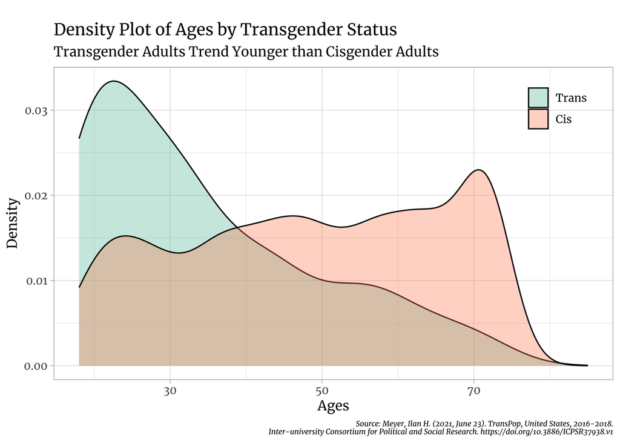

```r
#cis versus trans
ggplot(mydata, aes(AGE, weight=WEIGHT_CISGENDER_TRANSPOP, fill=TRANS_CIS))+
  geom_density(position="identity", alpha=.35)+
  xlim(18,85)+
  labs(
    title="Density Plot of Ages by Transgender Status",
    subtitle="Transgender Adults Trend Younger than Cisgender Adults",
    caption="Source: Meyer, Ilan H. (2021, June 23). TransPop, United States, 2016-2018.\n Inter-university Consortium for Political and Social Research. https://doi.org/10.3886/ICPSR37938.v1",
    tag="",
    x="Ages",
    y="Density",
    fill="") +
    theme_light(base_family="merri")+
    theme(legend.position = c(0.9, 0.9),
        legend.background = element_rect(fill = NA),
        plot.caption = element_text(face="italic", size = 6))+
    scale_fill_brewer(palette = "Set2", labels=c('Trans', 'Cis'))
```

After comparing the cisgender and transgender samples, I wanted to break down the transgender sample by gender identity. Doing so revealed some interesting trends. The curve for transgender women is the flattest of the three curves, suggesting that transgender women trend older than transgender men or nonbinary individuals. The data does not tell us why this is, although we can suggest some theories. For example, Lagos (2019) points out hormone therapy for transgender men tends to be more effective at masculinizing, while hormone therapy for transgender women is less effective at feminizing. Transgender men may find that after they pursue medical transition, they can effectively blend into the general population and may be less willing to partake in this type of survey than younger transgender men who are just beginning their transition. We also see that the curve for nonbinary individuals has the highest density of young people, which could reflect the relatively recent adoption of the term “nonbinary.” Older individuals who are gender nonconforming may not identify with that label, and therefore may not be fully represented in this sample.

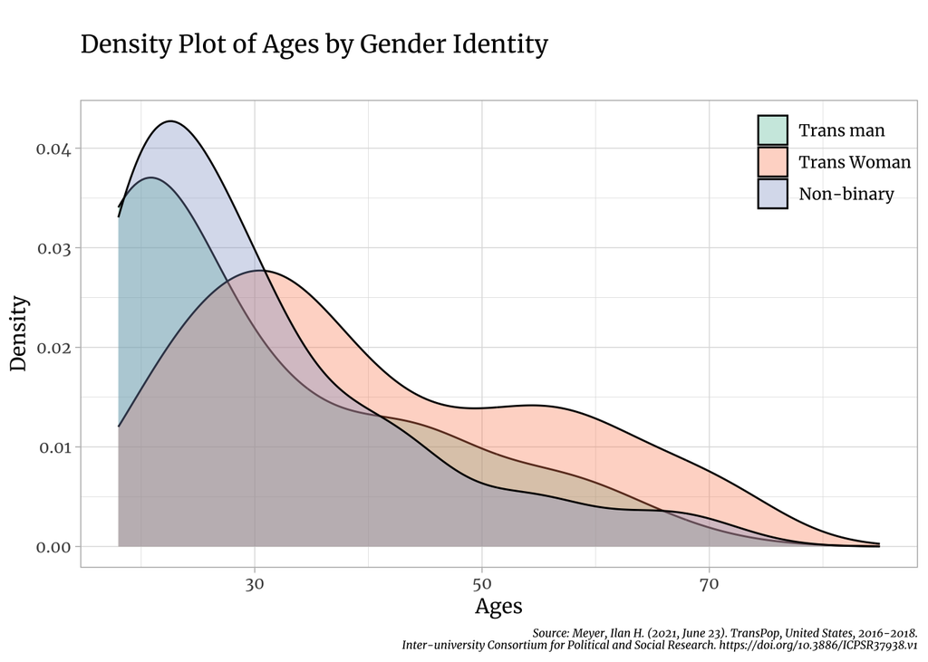

```r
#trans by gender identity

ggplot(transdata, aes(AGE, weight=WEIGHT_TRANSPOP, fill=GENDER_IDENTITY))+
  geom_density(position="identity", alpha=.35)+
  xlim(18,85)+
  labs(
    title="Density Plot of Ages by Gender Identity",
    subtitle="",
    caption="Source: Meyer, Ilan H. (2021, June 23). TransPop, United States, 2016-2018.\n Inter-university Consortium for Political and Social Research. https://doi.org/10.3886/ICPSR37938.v1",
    tag="",
    x="Ages",
    y="Density",
    fill="") +
    theme_light(base_family="merri")+
    theme(legend.position = c(0.9, 0.9),
        legend.background = element_rect(fill = NA),
        plot.caption = element_text(face="italic", size = 6))+
    scale_fill_brewer(palette = "Set2")
```

### Sexual Orientation

Looking at the sexual orientations of the two samples, we can see a stark difference between the cisgender and transgender samples. Although these two graphs could have been combined into one, I thought that keeping them separate showed the dramatic differences more clearly. In the transgender sample, we can see a wide array of gender identities represented. On the other hand, the cisgender sample has one primary bar in the bar chart, and a large amount of white space showing the lack of diversity in sexual orientations. While it would have been very interesting to facet the data further by gender identity, doing so would yield subsets too small to be representative or significant.

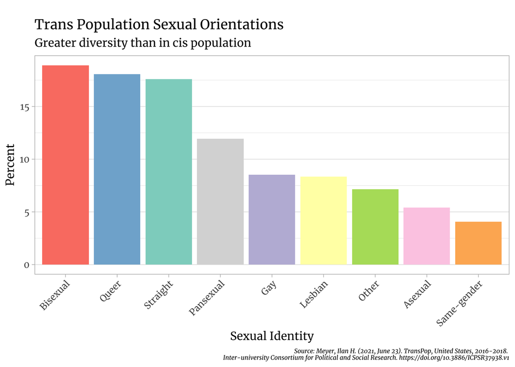

```r
#cis versus trans

#take a weighted table, convert to proportion table, then save as dataframe
#trans sample
transSI <- as.data.frame(prop.table(svytable(~SEXUALID, transdesign))*100)

ggplot(transSI, aes(fill=SEXUALID, reorder(SEXUALID, -Freq),weight=Freq))+
  geom_bar()+
    labs(
    title="Trans Population Sexual Orientations",
    subtitle="Greater diversity than in cis population",
    caption="Source: Meyer, Ilan H. (2021, June 23). TransPop, United States, 2016-2018. \n Inter-university Consortium for Political and Social Research. https://doi.org/10.3886/ICPSR37938.v1",
    tag="",
    x="Sexual Identity",
    y="Percent") +
    theme_light(base_family="merri")+
    theme(legend.position="none",
          plot.caption = element_text(face="italic", size = 6),
          panel.grid.major.x = element_blank(),
          axis.text.x = element_text(angle = 45, hjust=1))+
     scale_fill_brewer(palette = "Set3")
```

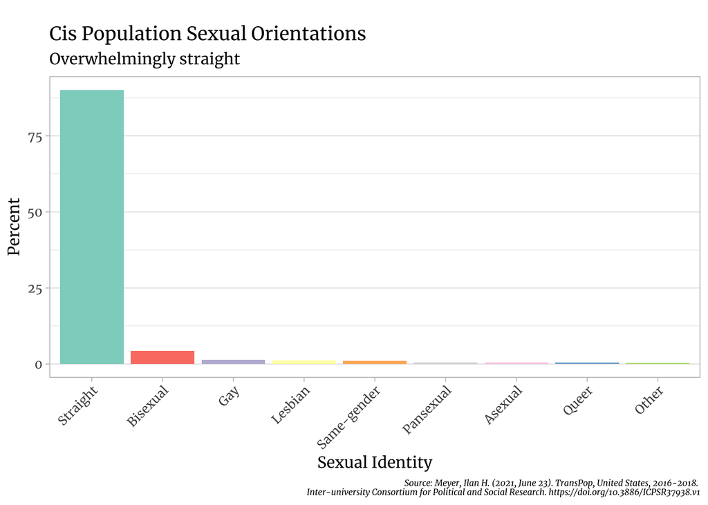

```r
#do the same for cis sample
cisSI <- as.data.frame(prop.table(svytable(~SEXUALID, cisdesign))*100)

ggplot(cisSI, aes(fill=SEXUALID, reorder(SEXUALID, -Freq),weight=Freq))+
  geom_bar()+
    labs(
    title="Cis Population Sexual Orientations",
    subtitle="Overwhelmingly straight",
    caption="Source: Meyer, Ilan H. (2021, June 23). TransPop, United States, 2016-2018. \n Inter-university Consortium for Political and Social Research. https://doi.org/10.3886/ICPSR37938.v1",
    tag="",
    x="Sexual Identity",
    y="Percent") +
    theme_light(base_family="merri")+
    theme(legend.position="none",
          plot.caption = element_text(face="italic", size = 6),
          panel.grid.major.x = element_blank(),
          axis.text.x = element_text(angle = 45, hjust=1))+
     scale_fill_brewer(palette = "Set3")
```

### Mental Health

For the next set of charts, I used a scale variable called the Kessler-6 scale, created by summing the results of six survey items. The data documentation suggested a score of 13 or above likely indicates serious mental illness, while a lower score indicates likely not having a serious mental illness (Meyer 2021). I created a new binary variable to represent this cut off and compared groups that fell into the two categories.

Comparing the cisgender and transgender population, there is a clearly a stronger tendency towards mental illness in the transgender community. It is important not to infer causation here and to keep in mind the many reasons transgender people may have more mental health challenges (experiencing frequent discrimination, violence, ostracization, etc).

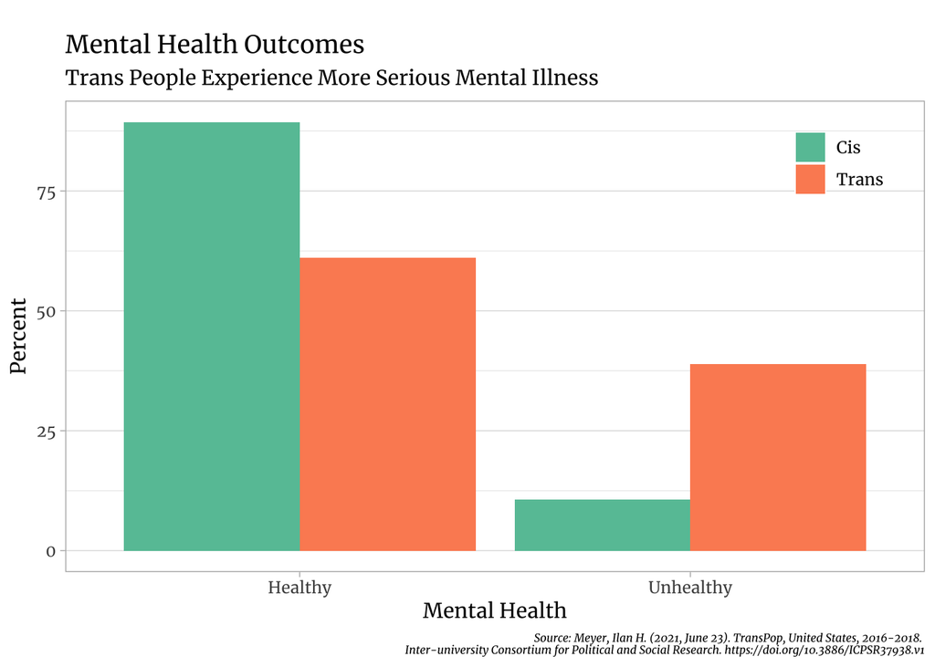

```r
#cis versus trans
#take weighted table of kesslerBinary variable, limit by cis sample
#use cisdesign weights, get proportions for just cis sample
Ckesstbl <- as.data.frame(prop.table(svytable(~kesslerBinary, cisdesign)))
Ckesstbl$CisTrans <- c("Cis", "Cis")

#do the same for trans sample
Tkesstbl <- as.data.frame(prop.table(svytable(~kesslerBinary, transdesign)))
Tkesstbl$CisTrans <- c("Trans", "Trans")

#combine the two dataframes in preparation for plotting
Combinedkesstbl <- rbind(Ckesstbl, Tkesstbl)

ggplot(Combinedkesstbl, aes(kesslerBinary, fill=CisTrans, weight=Freq*100))+
  geom_bar(position="dodge")+
  scale_x_discrete(labels=c("Healthy","Unhealthy"))+
  labs(
    title="Mental Health Outcomes",
    subtitle="Trans People Experience More Serious Mental Illness",
    caption="Source: Meyer, Ilan H. (2021, June 23). TransPop, United States, 2016-2018. \n Inter-university Consortium for Political and Social Research. https://doi.org/10.3886/ICPSR37938.v1",
    tag="",
    x="Mental Health",
    y="Percent",
    fill= "") +
    theme_light(base_family="merri")+
    theme(legend.position = c(0.9, 0.9),
        legend.background = element_rect(fill = NA),
          plot.caption = element_text(face="italic", size = 6),
          panel.grid.major.x = element_blank() ,)+
     scale_fill_brewer(palette = "Set2")
```

While the comparison with the cisgender sample is striking, the comparison across gender identities tells a surprising story. While transgender men and transgender women have nearly identical mental health outcomes, the mental health outcomes for nonbinary individuals are much worse. Within the gender identity groups, transgender men and transgender women have higher proportions of observations in the “health” mental health category, while the nonbinary subgroup has a higher proportion of individuals in the “unhealthy” category. The trend we see when comparing the cisgender sample with the entire transgender sample is skewed by the disproportionately worse mental health effects for nonbinary people.

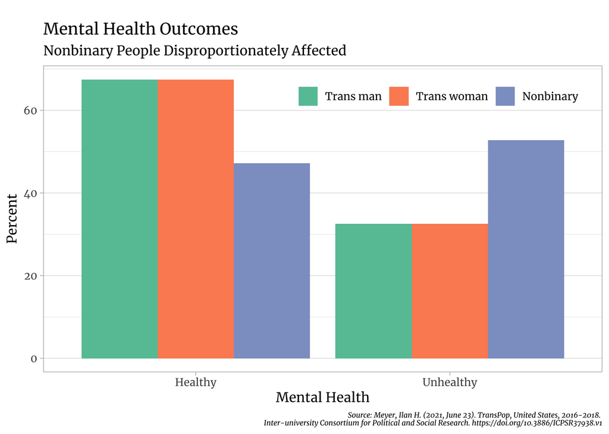

```r
#trans by gender identity
#take a weighted table of mental health by gender identity, turned into a prop table and summed down columns
kesstbl <- as.data.frame(prop.table(svytable(~kesslerBinary+GENDER_IDENTITY, transdesign), margin=2)*100)

#filter the table, only keeping trans gender identities
kesstbl <-
  kesstbl %>%
  filter(GENDER_IDENTITY == "Trans man" | GENDER_IDENTITY == "Trans Woman" | GENDER_IDENTITY == "Non-binary")

#plot the data
ggplot(kesstbl, aes(kesslerBinary, fill=GENDER_IDENTITY, weight=Freq)) +
  geom_bar(position="dodge")+
  scale_x_discrete(labels=c("Healthy","Unhealthy"))+
  labs(
    title="Mental Health Outcomes",
    subtitle="Nonbinary People Disproportionately Affected",
    caption="Source: Meyer, Ilan H. (2021, June 23). TransPop, United States, 2016-2018. \n Inter-university Consortium for Political and Social Research. https://doi.org/10.3886/ICPSR37938.v1",
    tag="",
    x="Mental Health",
    y="Percent",
    fill= "") +
    theme_light(base_family="merri")+
    theme(legend.position = c(0.7, 0.9),
          legend.direction="horizontal",
          legend.background = element_rect(fill = NA),
          plot.caption = element_text(face="italic", size = 6),
          panel.grid.major.x = element_blank() ,)+
     scale_fill_brewer(palette = "Set2", labels=c("Trans man", "Trans woman", "Nonbinary"))
```

### Suicidal Ideation

Looking at a variable dealing with suicidal ideation, we see these patterns continue. Comparing the cisgender and transgender samples yields an interesting bar chart that creates a mirror image. The cisgender sample skews heavily towards the “never had suicidal ideation” category while the transgender sample skews heavily towards the “had suicidal ideation more than once” category.

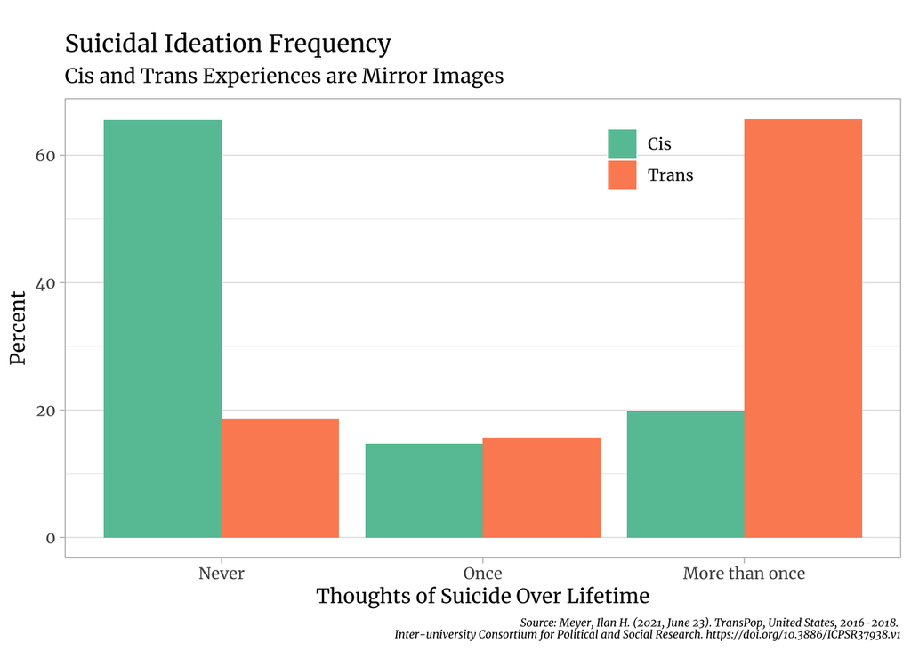

```r
#cis versus trans
#create dataframe with cis data based on cis weights
cisSI <- as.data.frame(prop.table(svytable(~Q128, cisdesign))*100)
#add a varable to the dataframe to label these rows as "cis"
cisSI$identity <- c("Cis", "Cis", "Cis")

#do the same for trans sample
transSI <- as.data.frame(prop.table(svytable(~Q128, transdesign))*100)
transSI$identity <- c("Trans", "Trans", "Trans")

#combine the tables then plot
rbind(cisSI, transSI) %>%
  ggplot(aes(Q128, fill=identity, weight=Freq)) +
  geom_bar(position="dodge") +
  scale_x_discrete(labels=c("Never","Once", "More than once"))+
  labs(
    title="Suicidal Ideation Frequency",
    subtitle="Cis and Trans Experiences are Mirror Images",
    caption="Source: Meyer, Ilan H. (2021, June 23). TransPop, United States, 2016-2018. \n Inter-university Consortium for Political and Social Research. https://doi.org/10.3886/ICPSR37938.v1",
    tag="",
    x="Thoughts of Suicide Over Lifetime",
    y="Percent",
    fill= "") +
    theme_light(base_family="merri")+
    theme(legend.position = c(0.7, 0.9),
          legend.direction="vertical",
          legend.background = element_rect(fill = NA),
          plot.caption = element_text(face="italic", size = 6),
          panel.grid.major.x = element_blank() ,)+
     scale_fill_brewer(palette = "Set2", labels=c("Cis", "Trans"))
```

Breaking this down further by gender identity, we see that once again nonbinary individuals seems to be the most vulnerable. Interestingly, we see that transgender women make up the largest portion of the “never had suicidal ideation” category on this chart. The differences in this chart are less dramatic and visually striking, suggesting we should do more research to determine whether there is really something happening here or if it was just a quirk of this sample.

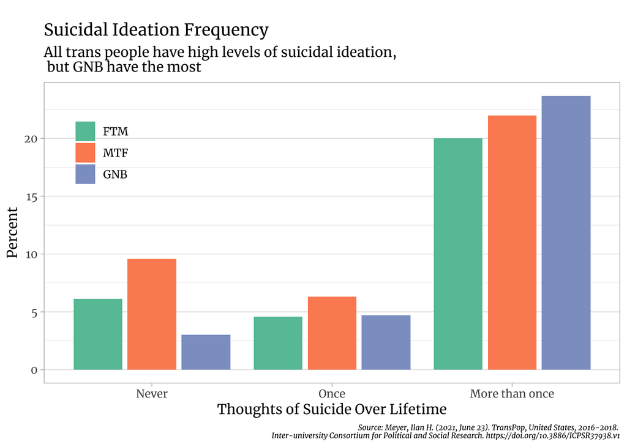

```r
#within trans community
transdata %>%
  drop_na(Q128) %>%
  ggplot(aes(x = Q128,
                   weight=WEIGHT_TRANSPOP,
                   fill=GENDER_IDENTITY)) +
  geom_bar(aes(y = (..count..)/sum(..count..)*100), #calculate proportions within ggplot
           position="dodge2") +
  scale_y_continuous() +
  scale_x_discrete(labels=c("Never","Once", "More than once"))+
  labs(
    title="Suicidal Ideation Frequency",
    subtitle="All trans people have high levels of suicidal ideation, \n but GNB have the most",
    caption="Source: Meyer, Ilan H. (2021, June 23). TransPop, United States, 2016-2018. \n Inter-university Consortium for Political and Social Research. https://doi.org/10.3886/ICPSR37938.v1",
    tag="",
    x="Thoughts of Suicide Over Lifetime",
    y="Percent",
    fill= "") +
    theme_light(base_family="merri")+
    theme(legend.position = c(0.1, 0.8),
          legend.direction="vertical",
          legend.background = element_rect(fill = NA),
          plot.caption = element_text(face="italic", size = 6),
          panel.grid.major.x = element_blank() ,)+
     scale_fill_brewer(palette = "Set2", labels=c("FTM", "MTF", "GNB"))
```

### Social perception of gender

So far, I have been comparing the transgender and cisgender samples and then further breaking down the transgender sample by gender identity. However, there are also some variables that only apply to the transgender community. In the next chart, I examine a variable created from the survey question “People can tell I am transgender even if I don’t tell them.” The response options range from “never” to “always.” Conceptually, this construct is a little unclear. The codebook says about this question, “The next questions are about your thoughts on gender expression and labels” (Meyer 2021). This question essentially asks transgender people to rank how often they are mistaken for a cisgender person, but there are multiple reasons a transgender person might be mistaken as cisgender. While in some cases, a transgender person who has sought medical transition may eventually be able to blend in with the cisgender population, other transgender people (and often nonbinary people) may never pursue medical transition. Where a transgender person falls on this scale relates that person’s presentation choices and access to desired transition related care. The TransPop survey took most of its survey questions from existing scales and other surveys on the transgender population (Meyer 2021). When doing so, and when researchers are interpreting the results, it is important to be very careful about understanding what construct the question is measuring.

I treated these responses as categorical variables, even though they are coded 1 – 5 in the survey. Since this is not an interval scale where we can conceptualize the distance between each response, it is inappropriate to average them. Instead, I plotted a bar chart based on the categories and then faceted the results by gender identity. Using faceting in this case, rather than side-by-side bars, makes it easier to see the overall trend for each gender identity.

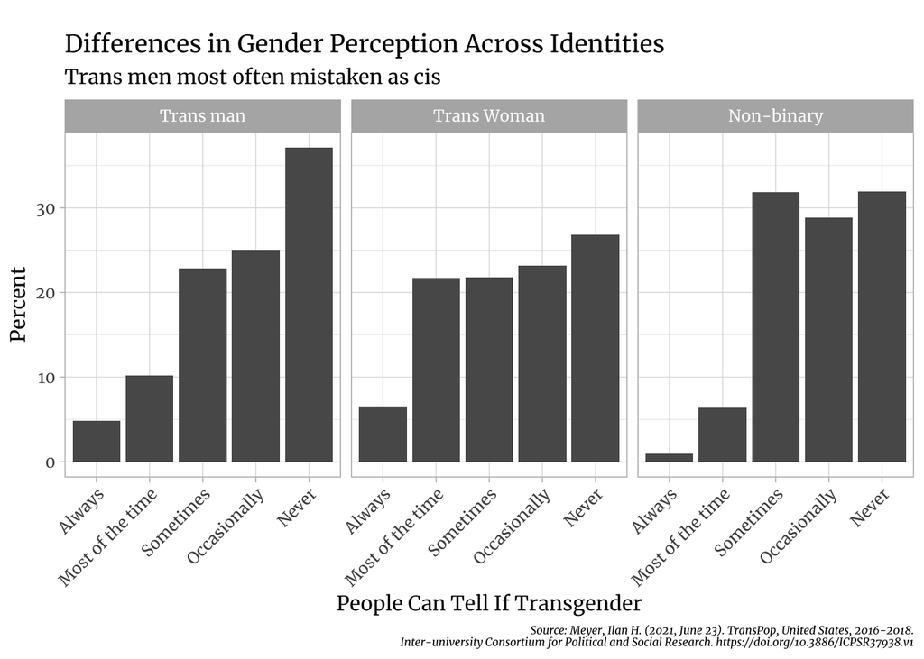

```r
Q44tbl <- as.data.frame(prop.table(svytable(~Q44+GENDER_IDENTITY, transdesign), margin=2)*100)

Q44tbl %>%
  drop_na(Freq) %>%
  ggplot(aes(Q44, weight=Freq)) +
  geom_bar()+
  facet_wrap(~GENDER_IDENTITY)+
  scale_x_discrete(labels= c("Always", "Most of the time", "Sometimes", "Occasionally", "Never"))+
  labs(
    title="Differences in Gender Perception Across Identities",
    subtitle="Trans men most often mistaken as cis",
    caption="Source: Meyer, Ilan H. (2021, June 23). TransPop, United States, 2016-2018.\n Inter-university Consortium for Political and Social Research. https://doi.org/10.3886/ICPSR37938.v1",
    tag="",
    x="People Can Tell If Transgender",
    y="Percent",
    fill="") +
    theme_light(base_family="merri")+
    theme(legend.position = c(0.9, 0.9),
        legend.background = element_rect(fill = NA),
        plot.caption = element_text(face="italic", size = 6),
        axis.text.x = element_text(angle = 45, hjust=1))+
    scale_fill_brewer(palette = "Set2")
```

As expected, we can see that transgender men trend most heavily towards the “never” end of the scale. This means that, based on their experience and perception, other people may never know that they are transgender, unless it is explicitly disclosed. On the other hand, transgender women trend the other direction, and out of the three groups are most likely to be identified as transgender without explicitly disclosing that information. It is interesting to note that very few respondents overall indicated “always”, as in people can always tell that they are transgender. However, transgender women do have the highest proportion of respondents in that category and have by far the highest proportion of respondents in the “most of the time” category. Most of the nonbinary responses fall in the “sometimes” to “never” categories. This chart supports the idea that different gender identities have different experiences and outcomes, and points to directions for new research.

### Discrimination

Finally, we look at measures of discrimination. For this measure, I wanted to facet data by race. While most of my project has been spent looking at differences among gender identities, in the interest of generating hypotheses, it is helpful to look at other intersections as well. This dataset is too small to stratify by both gender identity and race, especially since both the cisgender and transgender sample are largely white. Instead, I did a density plot to compare a measure of everyday discrimination faceted across races, with two curves – one for the cisgender sample and one for the transgender sample.

The results here are powerful because they are very consistent. We know that different races experience different levels of discrimination, and we see that in how the curves shift based on the facet. However, in every case the cisgender curve peaks further left on the x axis, indicating less discrimination. This shows that individuals’ transgender and racial identities compound the effects of discrimination. Even transgender individuals who are privileged in terms of race still experience more discrimination than their cisgender peers.

[interactive chart not shown]

## Conclusion

Future research should aim to collect larger samples that can be more effectively stratified into subsets, so that we can analyze the intersections between different identities. This project was very limited by the small size of the transgender sample. Most of the analysis looks at cisgender versus transgender samples and also provides a broad breakdown of gender identities. Future analysis should consider age, income, education, poverty, and other demographic information that can influence outcomes. For example, it would be important to know if income mediates poor outcomes – do transgender people in higher income brackets have better mental health and experience less discrimination? Other intersections of interest are measures of urbanicity and race.

Most importantly, research can no longer ignore the transgender population or aggregate their results under the umbrella of LGBT. This is a unique, diverse, and vulnerable group. Surveys should collect data on their participants’ gender identity rather than assuming everyone is cisgender and only providing “male” and “female” options for selecting sex. In particular, surveys must include options to represent nonbinary individuals, who may be one of the most vulnerable subsets of the transgender community. More research is required to identify why and to what extent we see worse outcomes for nonbinary individuals and whether this is mediated by any other factors.

## References

Clements-Nolle, K, R Marx, R Guzman, and M Katz. 2001. “HIV Prevalence, Risk Behaviors, Health Care Use, and Mental Health Status of Transgender Persons: Implications for Public Health Intervention.” American Journal of Public Health 91(6): 915–21.

Giblon, Rachel, and Greta R. Bauer. 2017. “Health Care Availability, Quality, and Unmet Need: A Comparison of Transgender and Cisgender Residents of Ontario, Canada.” BMC Health Services Research 17(1): 283.

Lagos, Danya. 2019. “Hearing Gender: Voice-Based Gender Classification Processes and Transgender Health Inequality.” American Sociological Review 84(5): 801–27

Meyer, Ilan H. 2021. TransPop, United States, 2016-2018. Inter-university Consortium for Political and Social Research. https://doi.org/10.3886/ICPSR37938.v1

Reisner, Sari L. et al. 2015. “Legal Protections in Public Accommodations Settings: A Critical Public Health Issue for Transgender and Gender-Nonconforming People.” The Milbank Quarterly 93(3): 484–515.